# HW1 ダイヤモンドの価格予測

参考解答

# 1. 読み込みと前処理

まずデータを読み込む。

```r
# 1. データを読み込む
library(ggplot2)
train <- read.csv("data/train.csv")
```

変数の意味を確認しながら、品質の低い順に水準を指定して因子化する。

```r
# 2. カテゴリ変数を factor にする（品質の低い順）
# cut：カットの品質（Fair → Ideal）
train$cut <- factor(train$cut,
                    levels = c("Fair", "Good", "Very Good", "Premium", "Ideal"))
# color：色の等級（J → D）
train$color <- factor(train$color,
                      levels = c("J", "I", "H", "G", "F", "E", "D"))
# clarity：透明度の等級（I1 → IF）
train$clarity <- factor(train$clarity,
                        levels = c("I1", "SI2", "SI1", "VS2", "VS1", "VVS2", "VVS1", "IF"))
```

重複と欠損を確認し、記述統計で平均・中央値・最小値・最大値を見て、外れ値の候補を確認する。

```r
# 3. 重複・欠損・記述統計を確認する
sum(duplicated(train$id))
```

```
## [1] 0
```

```r
sum(duplicated(train[c("carat", "cut", "color", "clarity", "depth",
                       "table", "x", "y", "z", "price")]))
```

```
## [1] 0
```

```r
colSums(is.na(train))
```

```
##      id   carat     cut   color clarity   depth   table       x       y       z
##       0       0       0       0       0       0       0       0       0       0
##   price
##       0
```

```r
# 平均・中央値・値の範囲を見て、外れ値の候補を確認する。
summary(train)
```

```
##        id            carat               cut       color       clarity
##  Min.   :12345   Min.   :0.2000   Fair     : 539   J:1016   SI1    :4697
##  1st Qu.:17145   1st Qu.:0.4000   Good     :1746   I:1902   VS2    :4325
##  Median :21944   Median :0.7000   Very Good:4375   H:2939   SI2    :3225
##  Mean   :21944   Mean   :0.7939   Premium  :4858   G:3991   VS1    :2916
##  3rd Qu.:26744   3rd Qu.:1.0400   Ideal    :7682   F:3465   VVS2   :1855
##  Max.   :31544   Max.   :4.0100                    E:3510   VVS1   :1286
##                                                    D:2377   (Other): 896
##      depth           table             x                y
##  Min.   :43.00   Min.   :50.00   Min.   : 3.730   Min.   : 3.680
##  1st Qu.:61.00   1st Qu.:56.00   1st Qu.: 4.710   1st Qu.: 4.730
##  Median :61.80   Median :57.00   Median : 5.690   Median : 5.710
##  Mean   :61.74   Mean   :57.45   Mean   : 5.723   Mean   : 5.729
##  3rd Qu.:62.50   3rd Qu.:59.00   3rd Qu.: 6.530   3rd Qu.: 6.530
##  Max.   :79.00   Max.   :76.00   Max.   :10.020   Max.   :58.900
##
##        z             price
##  Min.   :2.250   Min.   :  335
##  1st Qu.:2.910   1st Qu.:  945
##  Median :3.520   Median : 2390
##  Mean   :3.535   Mean   : 3910
##  3rd Qu.:4.030   3rd Qu.: 5278
##  Max.   :8.060   Max.   :18818
##
```

# 2. 多重共線性を確認する

相関計算用のコピーで因子を等級番号に変える。ここでは等級間を等間隔として Pearson 相関を計算する。回帰に使う列は因子のまま保持する。

```r
# 4. 相関係数を確認する
correlation_data <- train[c("carat", "cut", "color", "clarity", "depth",
                            "table", "x", "y", "z", "price")]
correlation_data$cut <- as.integer(train$cut)
correlation_data$color <- as.integer(train$color)
correlation_data$clarity <- as.integer(train$clarity)
correlation_matrix <- cor(correlation_data)
correlation_matrix
```

|  | carat | cut | color | clarity | depth | table | x | y | z | price |
| --- | --- | --- | --- | --- | --- | --- | --- | --- | --- | --- |
| carat | 1.00 | -0.13 | -0.28 | -0.35 | 0.04 | 0.18 | 0.98 | 0.93 | 0.98 | 0.92 |
| cut | -0.13 | 1.00 | 0.01 | 0.19 | -0.22 | -0.44 | -0.12 | -0.11 | -0.15 | -0.05 |
| color | -0.28 | 0.01 | 1.00 | -0.02 | -0.05 | -0.02 | -0.27 | -0.25 | -0.27 | -0.16 |
| clarity | -0.35 | 0.19 | -0.02 | 1.00 | -0.07 | -0.16 | -0.37 | -0.35 | -0.38 | -0.15 |
| depth | 0.04 | -0.22 | -0.05 | -0.07 | 1.00 | -0.29 | -0.02 | -0.02 | 0.10 | 0.00 |
| table | 0.18 | -0.44 | -0.02 | -0.16 | -0.29 | 1.00 | 0.19 | 0.18 | 0.15 | 0.12 |
| x | 0.98 | -0.12 | -0.27 | -0.37 | -0.02 | 0.19 | 1.00 | 0.95 | 0.99 | 0.89 |
| y | 0.93 | -0.11 | -0.25 | -0.35 | -0.02 | 0.18 | 0.95 | 1.00 | 0.95 | 0.84 |
| z | 0.98 | -0.15 | -0.27 | -0.38 | 0.10 | 0.15 | 0.99 | 0.95 | 1.00 | 0.88 |
| price | 0.92 | -0.05 | -0.16 | -0.15 | 0.00 | 0.12 | 0.89 | 0.84 | 0.88 | 1.00 |

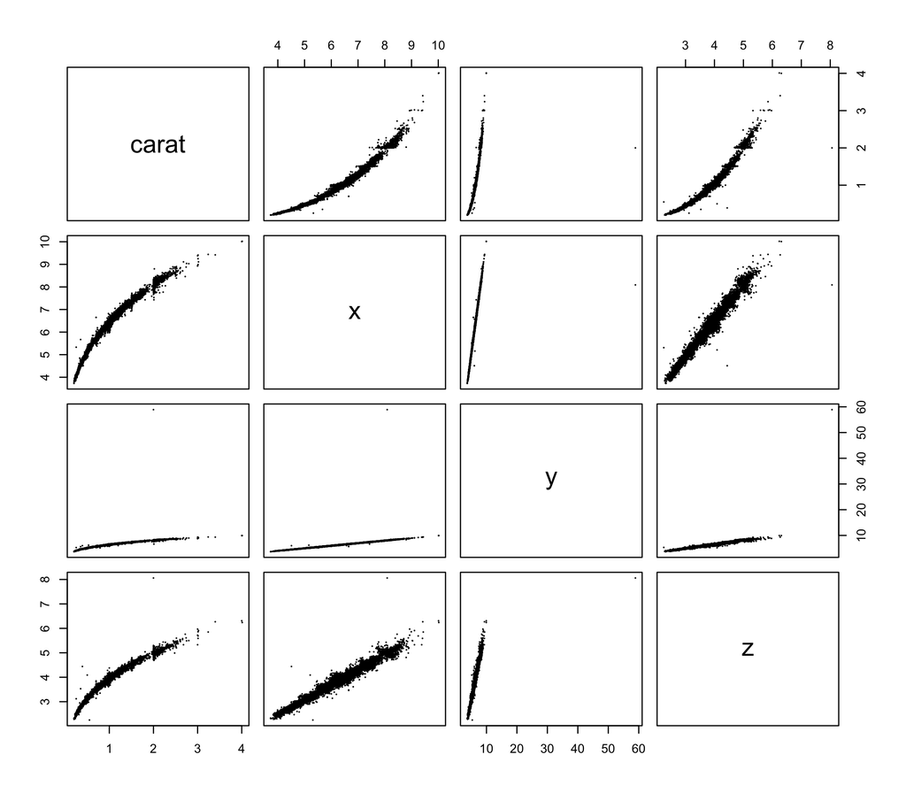

```r
# 重量と寸法の関係
pairs(train[c("carat", "x", "y", "z")], pch = 16, cex = 0.3)
```

`carat` と `x` の相関は 0.978、`x` と `z` は 0.991 だった。重量と寸法は同じ「石の大きさ」の情報を多く含み、同時に使うとそれぞれの係数を分けて推定しにくい。

# 3. 価格の非線形な関係を見る

価格は低価格帯に集中し、高価格側に長い裾を持つ。

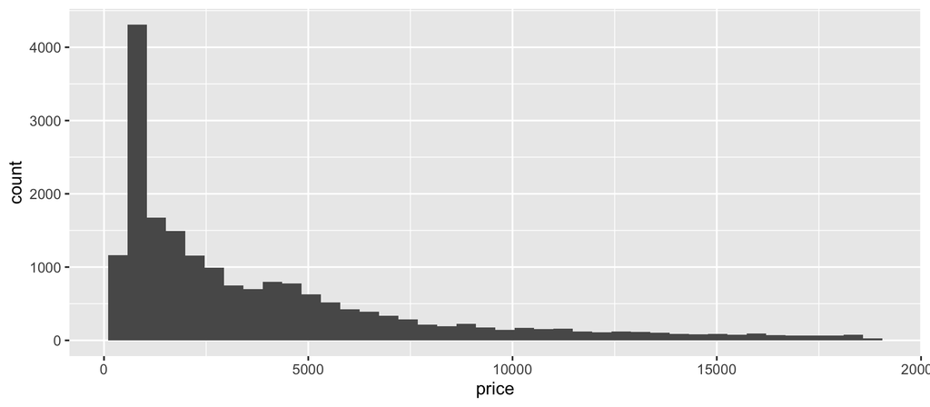

```r
# 5. 価格の分布
print(ggplot(train, aes(x = price)) +
  geom_histogram(bins = 40))
```

カットを Ideal、色を G、透明度を VS2 にそろえ、重量と価格の関係を見る。学習には全データを使う。

```r
# 品質をそろえて、非線形をチェック
quality_data <- subset(train, cut == "Ideal" & color == "G" & clarity == "VS2")
```

赤は直線、青は二次曲線。価格の上昇は非線形なので、二乗や対数変換を試す。

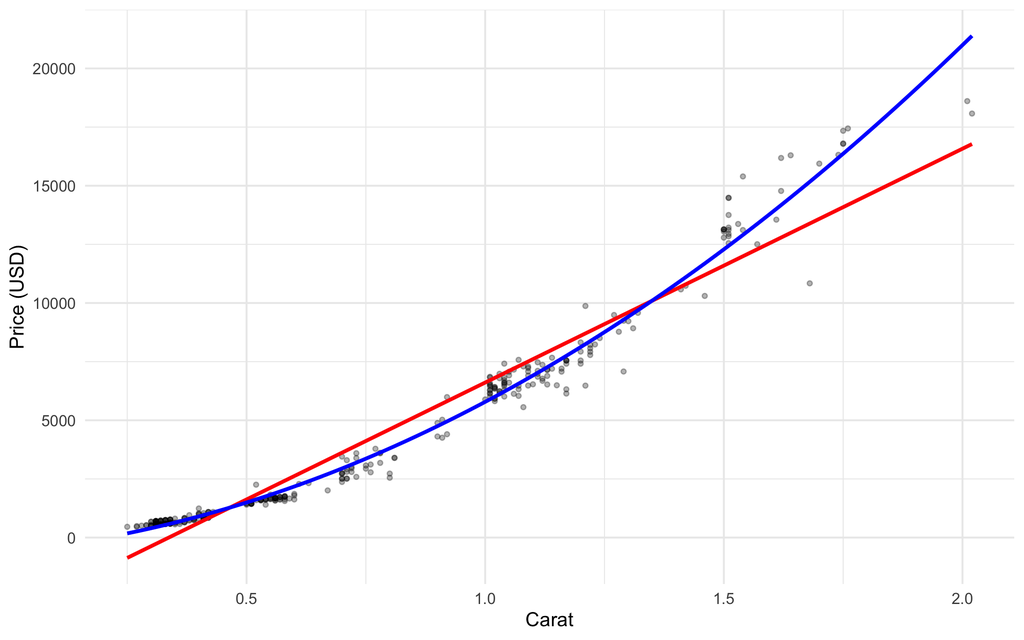

```r
print(ggplot(quality_data, aes(x = carat, y = price)) +
  geom_point(alpha = 0.3, size = 1) +
  geom_smooth(method = "lm", formula = y ~ x, se = FALSE, color = "red") +
  geom_smooth(method = "lm", formula = y ~ x + I(x^2), se = FALSE, color = "blue") +
  labs(x = "Carat", y = "Price (USD)") +
  theme_minimal())
```

価格と重量の両方を対数にすると、関係が直線に近づく。

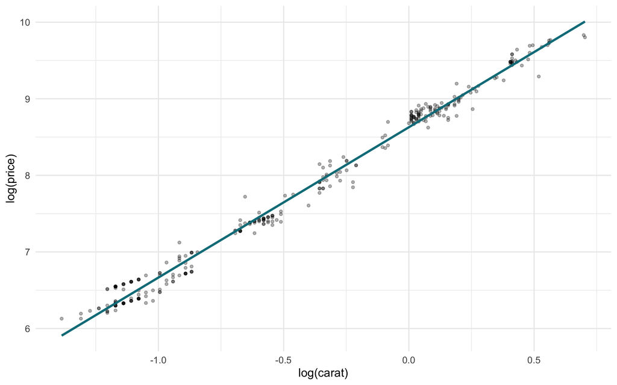

```r
print(ggplot(quality_data, aes(x = log(carat), y = log(price))) +
  geom_point(alpha = 0.3, size = 1) +
  geom_smooth(method = "lm", formula = y ~ x, se = FALSE, color = "#087d89") +
  labs(x = "log(carat)", y = "log(price)") +
  theme_minimal())
```

# 4. 4つのモデルを比較する

同じ80%／20%分割で比較する。乱数シードは2026に固定する。

```r
# 6. データの分割
set.seed(2026)
train_index <- sample(nrow(train), size = 0.8 * nrow(train))
training <- train[train_index, ]
validation <- train[-train_index, ]
```

全変数、重量と品質、平方項と交差項、両対数の4通りを当てはめる。

```r
# 7. モデルの推定
model1 <- lm(price ~ carat + cut + color + clarity + depth + table + x + y + z,
             data = training)
model2 <- lm(price ~ carat + cut + color + clarity, data = training)
model3 <- lm(price ~ carat * (cut + color + clarity) + I(carat^2), data = training)
model4 <- lm(log(price) ~ log(carat) + cut + color + clarity, data = training)
```

`I(carat^2)` は平方項である。`carat * (cut + color + clarity)` は、交差項を追加し、重量が価格に与える影響を cut・color・clarity によって変えられるようにする。

log-log モデルは `exp()` でドルに戻す。4つともドル単位の RMSE で評価する。

```r
# 8. 検証用データを予測する。log-log モデルはドルに戻す。
prediction1 <- predict(model1, newdata = validation)
prediction2 <- predict(model2, newdata = validation)
prediction3 <- predict(model3, newdata = validation)
prediction4 <- exp(predict(model4, newdata = validation))
```

```r
RMSE <- c(
  M1 = sqrt(mean((validation$price - prediction1)^2)),
  M2 = sqrt(mean((validation$price - prediction2)^2)),
  M3 = sqrt(mean((validation$price - prediction3)^2)),
  M4 = sqrt(mean((validation$price - prediction4)^2))
)
print(round(RMSE, 2))
```

```
##      M1      M2      M3      M4
## 1150.91 1190.33  841.68  781.12
```

| モデル | 内容 | RMSE |
| --- | --- | --- |
| M1 | 全変数 | 1150.91 |
| M2 | 重量と品質 | 1190.33 |
| M3 | 平方項＋交差項 | 841.68 |
| M4 | 両対数 | 781.12 |

全変数の M1 は重量と品質の M2 より少し良いが、平方項と交差項を使う M3 はさらに改善する。両対数の M4 が 781.12 ドルで最小だった。変数を全部入れることより、重量と品質の関係を表す式の工夫が今回の改善につながった。